# ANALYZING THE EFFECT OF VIOLENT VIDEO GAME PLAY ON MATE VALUE AND OTHER MATING RELATED VARIABLES

## General housekeeping

First load the libraries that we are using

```r
library(ggplot2)
library(knitr)
library(plyr)
library(tidyr)
```

```r
data = read.csv("All_Experiments.csv")
```

Attach and check the headers of each column

```r
names(data)
```

```
##  [1] "study"                    "subject"
##  [3] "Age"                      "Sex"
##  [5] "Averagefrequencyviolence" "Gameplayed"
##  [7] "VorNV"                    "Score"
##  [9] "Selfscore"                "Kinsey"
## [11] "Relationshipstatus"       "lengthofrelationship"
## [13] "ageofpartner"             "MV1Total"
## [15] "MV2Average"               "SGAAverage"
## [17] "HostilityTotal"           "SOIRTOTAL"
## [19] "Removedata"               "Rank"
## [21] "TotalSTScore"             "TotalLTScore"
```

Delete Rows where participants were unable to load or play game, had issues with the survey loading, or failed an attention check (144 people). Also delete rows where participants recorded gender as “Other” (2 people).

```r
data<-data[-which(data$Removedata == "Yes"), ]
data<-data[-which(data$Sex == "Other"), ]
```

Remove individuals that have a relationship status of ‘other’ (13 individuals)

```r
data = subset(data, Relationshipstatus %in% c("Single", "In an open relationship/casually dating", "In a long-term monogamous relationship eg. married, partnered", "Recently single/divorced/separated"))
```

Subset data into the three experiments

```r
data_gaming = subset(data, study=="Gaming_manipulation")
data_rank = subset(data, study=="Rank_manipulation")
data_faces = subset(data, study=="Face_choice")
```

[output not shown]

First, check the distributions of all the variables of interest

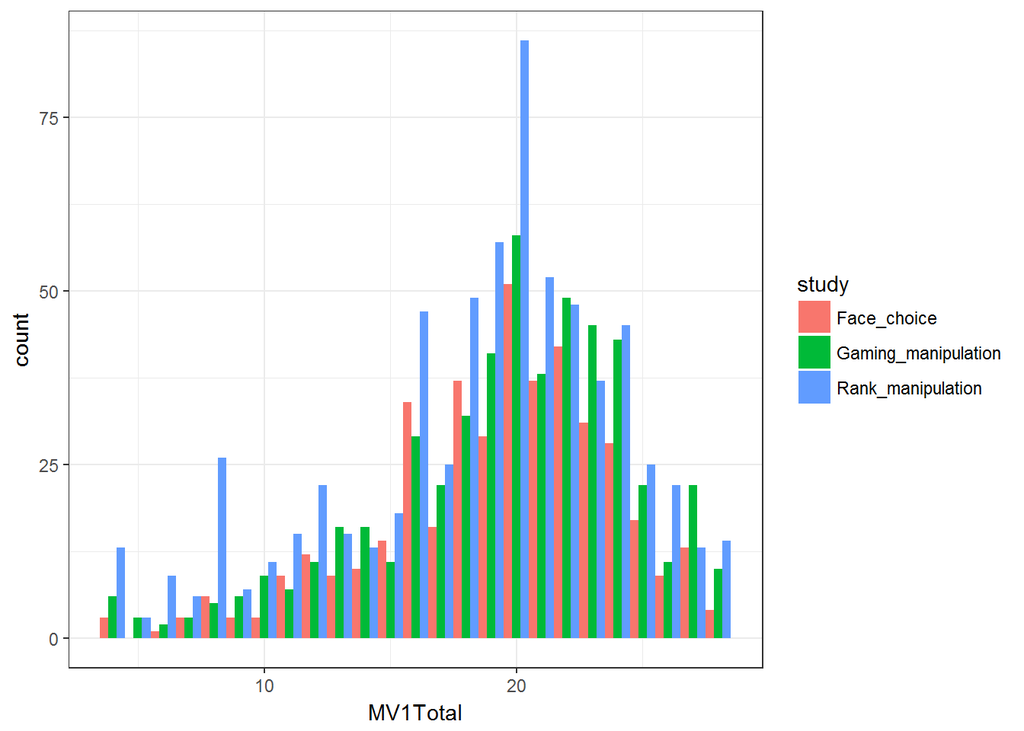

```r
ggplot(data,aes(x=MV1Total,group=study,fill=study))+
  geom_histogram(position="dodge",binwidth=1)+theme_bw()
```

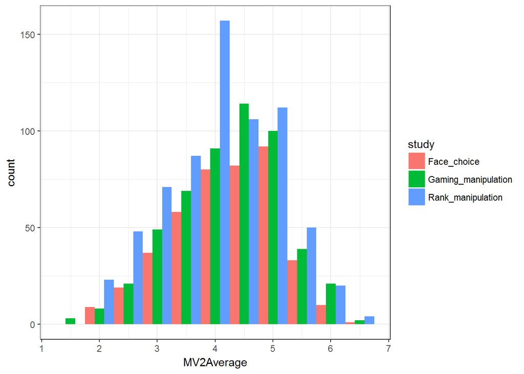

```r
ggplot(data,aes(x=MV2Average,group=study,fill=study))+
  geom_histogram(position="dodge",binwidth=0.5)+theme_bw()
```

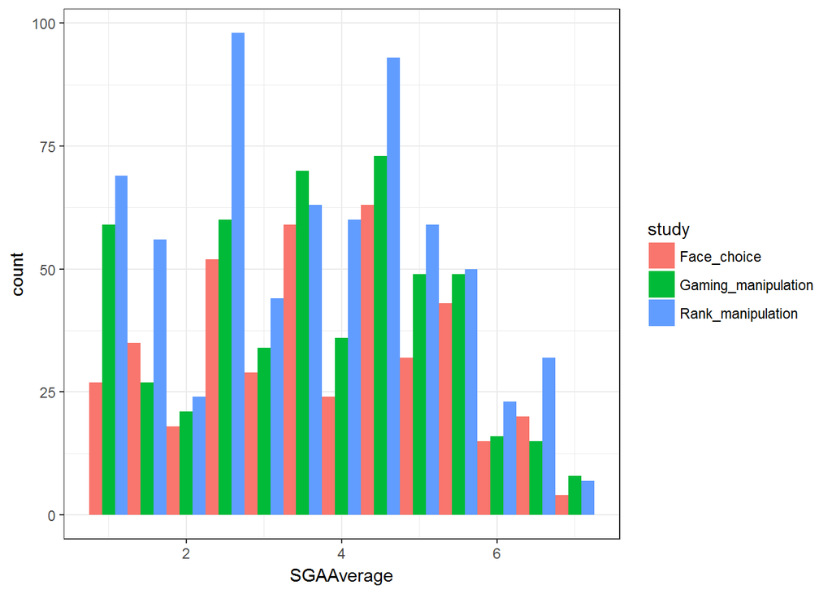

```r
ggplot(data,aes(x=SGAAverage,group=study,fill=study))+
  geom_histogram(position="dodge",binwidth=0.5)+theme_bw()
```

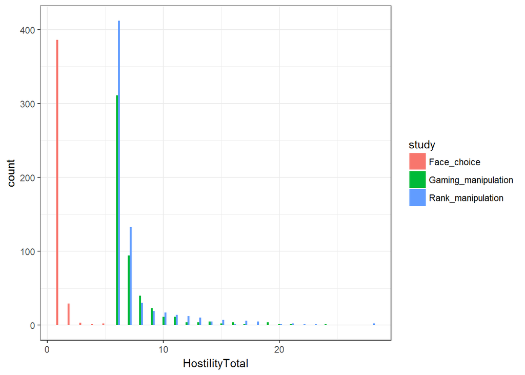

```r
ggplot(data,aes(x=HostilityTotal,group=study,fill=study))+
  geom_histogram(position="dodge",binwidth=0.5)+theme_bw()
```

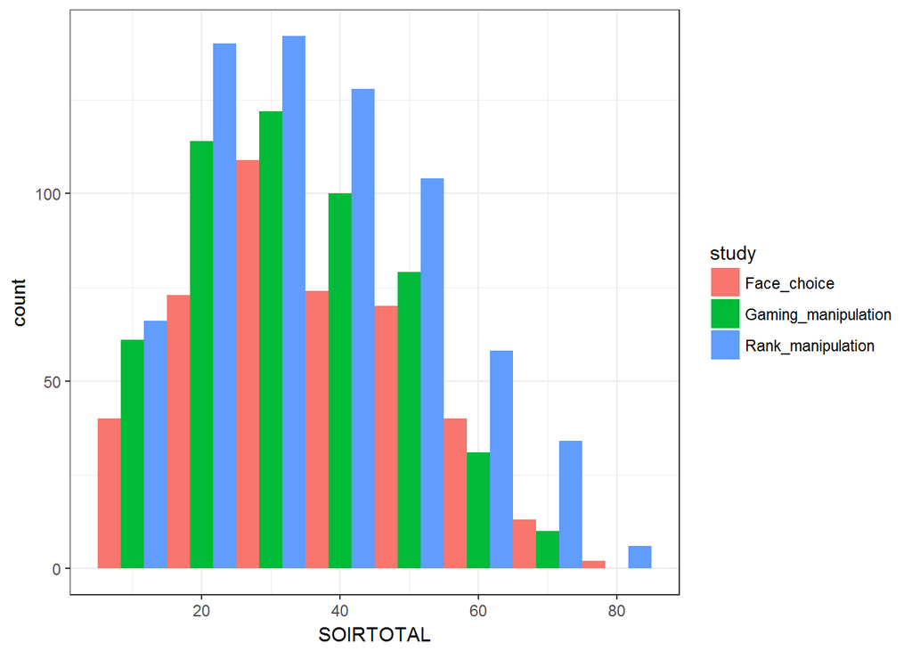

```r
ggplot(data,aes(x=SOIRTOTAL,group=study,fill=study))+
  geom_histogram(position="dodge",binwidth=10)+theme_bw()
```

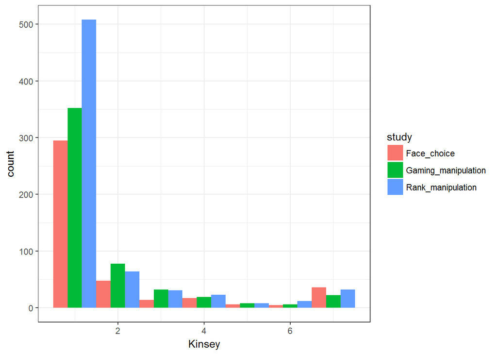

```r
ggplot(data,aes(x=Kinsey,group=study,fill=study))+
  geom_histogram(position="dodge",binwidth=1)+theme_bw()
```

The distributions for all of them are fine, except for Hostility Total. HT specifically has very little variation in it, so I don’t think it will be very useful and am happy to remove it from the models.

What is the mean, SD and range of the age of respondents in each study?

```r
ddply(data,~study,summarise,mean=mean(Age),sd=sd(Age), min=min(Age), max=max(Age))
```

```
##                 study     mean        sd min max
## 1         Face_choice 33.78147  9.419571  18  71
## 2 Gaming_manipulation 31.83752  9.761532  18  68
## 3   Rank_manipulation 35.28171 10.413830  18  74
```

How many men and women, and their relationship details

```r
table(data_gaming$Sex)
```

```
##
## Female   Male  Other
##    248    269      0
```

```r
table(data_rank$Sex)
```

```
##
## Female   Male  Other
##    310    368      0
```

```r
table(data_faces$Sex)
```

```
##
## Female   Male  Other
##    176    245      0
```

```r
table(data_gaming$Relationshipstatus)
```

```
##
## In a long-term monogamous relationship eg. married, partnered
##                                                           293
##                       In an open relationship/casually dating
##                                                            26
##                                                         Other
##                                                             0
##                            Recently single/divorced/separated
##                                                            16
##                                                        Single
##                                                           182
```

```r
table(data_rank$Relationshipstatus)
```

```
##
## In a long-term monogamous relationship eg. married, partnered
##                                                           369
##                       In an open relationship/casually dating
##                                                            25
##                                                         Other
##                                                             0
##                            Recently single/divorced/separated
##                                                            21
##                                                        Single
##                                                           263
```

```r
table(data_faces$Relationshipstatus)
```

```
##
## In a long-term monogamous relationship eg. married, partnered
##                                                           258
##                       In an open relationship/casually dating
##                                                            23
##                                                         Other
##                                                             0
##                            Recently single/divorced/separated
##                                                            13
##                                                        Single
##                                                           127
```

## Exploration of between study differences

Do men and women differ in the amount of violent video games they play (self-rated)

```r
VVGDemo <- lm(Averagefrequencyviolence ~  Age + Sex + study + Age*Sex + study*Sex + study*Age, data=data)
anova(VVGDemo, test="Chisq")
```

```
## Analysis of Variance Table
##
## Response: Averagefrequencyviolence
##             Df Sum Sq Mean Sq  F value  Pr(>F)
## Age          1   8505  8504.8 100.2556 < 2e-16 ***
## Sex          1   9129  9128.5 107.6076 < 2e-16 ***
## study        2    737   368.3   4.3413 0.01317 *
## Age:Sex      1     30    30.4   0.3578 0.54982
## Sex:study    2     54    27.0   0.3184 0.72738
## Age:study    2    263   131.7   1.5520 0.21215
## Residuals 1606 136239    84.8
## ---
## Signif. codes:  0 '***' 0.001 '**' 0.01 '*' 0.05 '.' 0.1 ' ' 1
```

```r
summary(VVGDemo, test="Chisq")
```

```
##
## Call:
## lm(formula = Averagefrequencyviolence ~ Age + Sex + study + Age *
##     Sex + study * Sex + study * Age, data = data)
##
## Residuals:
##     Min      1Q  Median      3Q     Max
## -22.173  -6.604  -0.797   6.132  32.073
##
## Coefficients:
##                                   Estimate Std. Error t value Pr(>|t|)
## (Intercept)                      18.395721   2.049312   8.977  < 2e-16 ***
## Age                              -0.148641   0.055197  -2.693  0.00716 **
## SexMale                           5.407969   1.840865   2.938  0.00335 **
## studyGaming_manipulation         -1.300973   2.395487  -0.543  0.58714
## studyRank_manipulation            2.943918   2.275606   1.294  0.19596
## Age:SexMale                      -0.032315   0.046833  -0.690  0.49030
## SexMale:studyGaming_manipulation  0.502357   1.238212   0.406  0.68501
## SexMale:studyRank_manipulation    0.706948   1.164152   0.607  0.54376
## Age:studyGaming_manipulation     -0.001235   0.064267  -0.019  0.98467
## Age:studyRank_manipulation       -0.083104   0.059147  -1.405  0.16021
## ---
## Signif. codes:  0 '***' 0.001 '**' 0.01 '*' 0.05 '.' 0.1 ' ' 1
##
## Residual standard error: 9.21 on 1606 degrees of freedom
## Multiple R-squared:  0.1208, Adjusted R-squared:  0.1159
## F-statistic: 24.52 on 9 and 1606 DF,  p-value: < 2.2e-16
```

HISTOGRAM

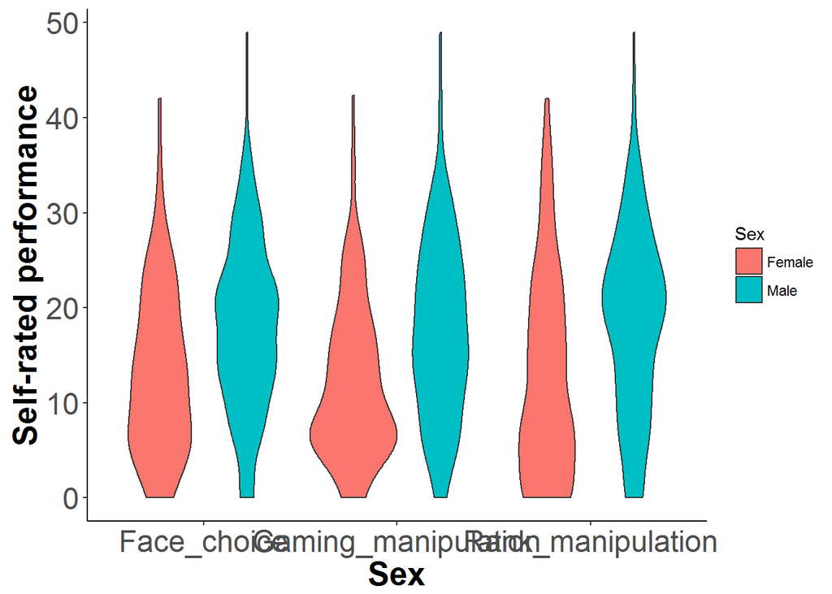

```r
ggplot(data, aes(x=study, y=Averagefrequencyviolence, fill=Sex)) + geom_violin() +
  xlab("Sex") +
  ylab("Self-rated performance") +
  theme(axis.line = element_line(colour = "black"),
        axis.text=element_text(size=18),
        axis.title=element_text(size=20,face="bold"),
        axis.title.y=element_text(vjust=0.25),
        axis.title.x=element_text(vjust=0.25),
        panel.grid.major = element_blank(),
        panel.grid.minor = element_blank(),
        panel.border = element_blank(),
        panel.background = element_blank())
```

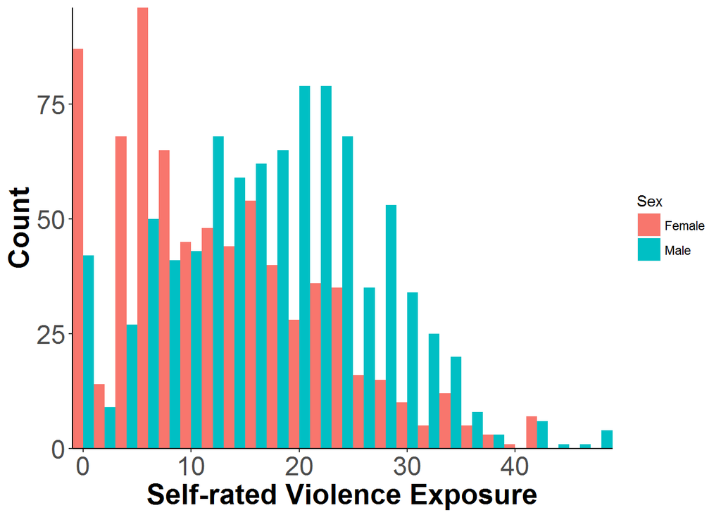

```r
ggplot(data, aes(x=Averagefrequencyviolence, fill=Sex)) +
  geom_histogram(binwidth=2, position="dodge") +
  xlab("Self-rated Violence Exposure") +
  ylab("Count") +
  scale_x_continuous(expand = c(0, 0)) + scale_y_continuous(expand = c(0, 0)) +
  theme(axis.line = element_line(colour = "black"),
        plot.title = element_text(size=30, face="bold"),
        legend.position = "right",
        axis.text=element_text(size=18),
        axis.title=element_text(size=20,face="bold"),
        panel.grid.major = element_blank(),
        panel.grid.minor = element_blank(),
        panel.border = element_blank(),
        panel.background = element_blank())
```

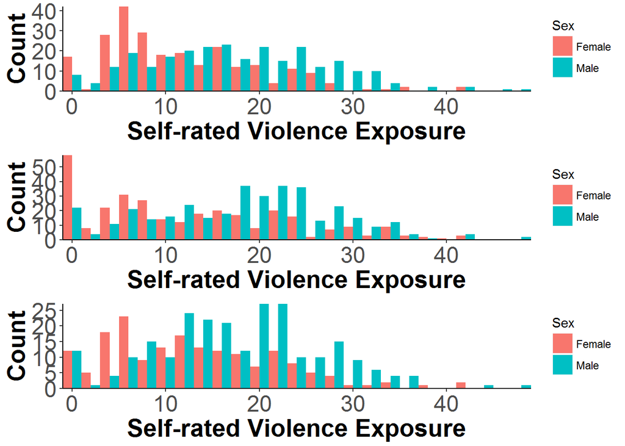

```r
gaming_hist <- ggplot(data_gaming, aes(x=Averagefrequencyviolence, fill=Sex)) +
  geom_histogram(binwidth=2, position="dodge") +
  xlab("Self-rated Violence Exposure") +
  ylab("Count") +
  scale_x_continuous(expand = c(0, 0)) + scale_y_continuous(expand = c(0, 0)) +
  theme(axis.line = element_line(colour = "black"),
        plot.title = element_text(size=30, face="bold"),
        legend.position = "right",
        axis.text=element_text(size=18),
        axis.title=element_text(size=20,face="bold"),
        panel.grid.major = element_blank(),
        panel.grid.minor = element_blank(),
        panel.border = element_blank(),
        panel.background = element_blank())

rank_hist <- ggplot(data_rank, aes(x=Averagefrequencyviolence, fill=Sex)) +
  geom_histogram(binwidth=2, position="dodge") +
  xlab("Self-rated Violence Exposure") +
  ylab("Count") +
  scale_x_continuous(expand = c(0, 0)) + scale_y_continuous(expand = c(0, 0)) +
  theme(axis.line = element_line(colour = "black"),
        plot.title = element_text(size=30, face="bold"),
        legend.position = "right",
        axis.text=element_text(size=18),
        axis.title=element_text(size=20,face="bold"),
        panel.grid.major = element_blank(),
        panel.grid.minor = element_blank(),
        panel.border = element_blank(),
        panel.background = element_blank())

face_hist <- ggplot(data_faces, aes(x=Averagefrequencyviolence, fill=Sex)) +
  geom_histogram(binwidth=2, position="dodge") +
  xlab("Self-rated Violence Exposure") +
  ylab("Count") +
  scale_x_continuous(expand = c(0, 0)) + scale_y_continuous(expand = c(0, 0)) +
  theme(axis.line = element_line(colour = "black"),
        plot.title = element_text(size=30, face="bold"),
        legend.position = "right",
        axis.text=element_text(size=18),
        axis.title=element_text(size=20,face="bold"),
        panel.grid.major = element_blank(),
        panel.grid.minor = element_blank(),
        panel.border = element_blank(),
        panel.background = element_blank())

multiplot(gaming_hist, rank_hist, face_hist, cols=1)
```

Relationship between Age, Sex, and Exposure to violence:

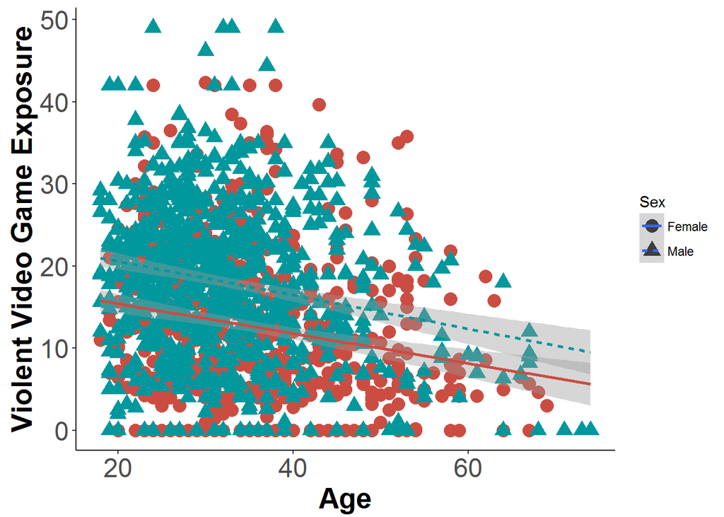

```r
ggplot(data, aes(x = Age, y = Averagefrequencyviolence, color = Sex, shape = Sex, linetype = Sex)) +
  geom_point(size = 4) +
  scale_colour_hue(l=50, guide = FALSE) +
  theme_bw() + geom_smooth(method=lm,  fullrange=T) +
  xlab("Age") +
  ylab("Violent Video Game Exposure") +
    theme(axis.line = element_line(colour = "black"),
        axis.text=element_text(size=18),
        axis.title=element_text(size=20,face="bold"),
        axis.title.y=element_text(vjust=0.25),
        axis.title.x=element_text(vjust=0.25),
        panel.grid.major = element_blank(),
        panel.grid.minor = element_blank(),
        panel.border = element_blank(),
        panel.background = element_blank())
```

## Experiment 1: Gaming Manipulation

Do men and women differ in how well they performed in the game in both self-rated (selfscore) and actual performance

```r
Perf <- lm(Selfscore ~  Age + Sex + VorNV + Age*VorNV + Sex*VorNV, data = data_gaming)
anova(Perf, test="Chisq")
```

```
## Analysis of Variance Table
##
## Response: Selfscore
##            Df Sum Sq Mean Sq F value    Pr(>F)
## Age         1  40.90  40.902 22.1407 3.266e-06 ***
## Sex         1  41.07  41.071 22.2326 3.120e-06 ***
## VorNV       1  62.36  62.362 33.7578 1.099e-08 ***
## Age:VorNV   1   2.37   2.368  1.2816    0.2581
## Sex:VorNV   1   0.61   0.612  0.3314    0.5651
## Residuals 511 944.00   1.847
## ---
## Signif. codes:  0 '***' 0.001 '**' 0.01 '*' 0.05 '.' 0.1 ' ' 1
```

```r
summary(Perf, test="Chisq")
```

```
##
## Call:
## lm(formula = Selfscore ~ Age + Sex + VorNV + Age * VorNV + Sex *
##     VorNV, data = data_gaming)
##
## Residuals:
##     Min      1Q  Median      3Q     Max
## -3.4902 -0.9239  0.0321  0.9119  3.9392
##
## Coefficients:
##                Estimate Std. Error t value Pr(>|t|)
## (Intercept)     4.27637    0.34142  12.525  < 2e-16 ***
## Age            -0.01469    0.00963  -1.525  0.12782
## SexMale         0.56635    0.17404   3.254  0.00121 **
## VorNVV         -0.36777    0.46161  -0.797  0.42598
## Age:VorNVV     -0.01266    0.01267  -0.999  0.31810
## SexMale:VorNVV  0.14106    0.24504   0.576  0.56509
## ---
## Signif. codes:  0 '***' 0.001 '**' 0.01 '*' 0.05 '.' 0.1 ' ' 1
##
## Residual standard error: 1.359 on 511 degrees of freedom
## Multiple R-squared:  0.135,  Adjusted R-squared:  0.1265
## F-statistic: 15.95 on 5 and 511 DF,  p-value: 1.292e-14
```

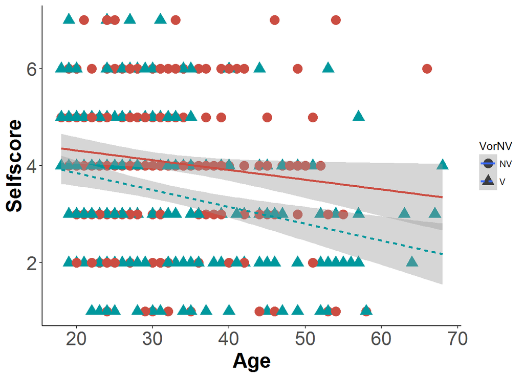

```r
ggplot(data_gaming, aes(x = Age, y = Selfscore, color = VorNV, shape = VorNV, linetype = VorNV)) +
  geom_point(size = 4) +
  scale_colour_hue(l=50, guide = FALSE) +
  theme_bw() + geom_smooth(method=lm,  fullrange=T) +
  xlab("Age") +
  ylab("Selfscore") +
    theme(axis.line = element_line(colour = "black"),
        axis.text=element_text(size=18),
        axis.title=element_text(size=20,face="bold"),
        axis.title.y=element_text(vjust=0.25),
        axis.title.x=element_text(vjust=0.25),
        panel.grid.major = element_blank(),
        panel.grid.minor = element_blank(),
        panel.border = element_blank(),
        panel.background = element_blank())
```

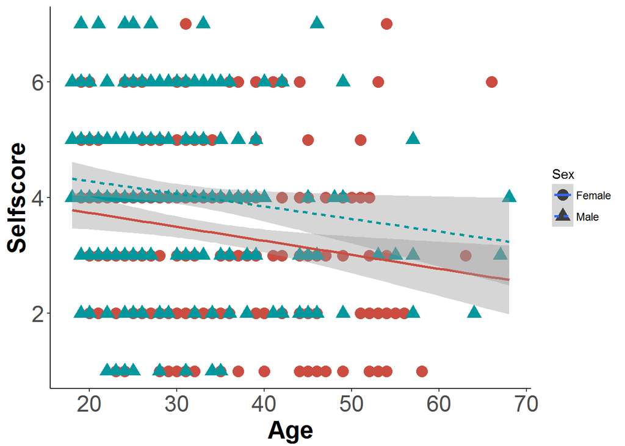

```r
ggplot(data_gaming, aes(x = Age, y = Selfscore, color = Sex, shape = Sex, linetype = Sex)) +
  geom_point(size = 4) +
  scale_colour_hue(l=50, guide = FALSE) +
  theme_bw() + geom_smooth(method=lm,  fullrange=T) +
  xlab("Age") +
  ylab("Selfscore") +
    theme(axis.line = element_line(colour = "black"),
        axis.text=element_text(size=18),
        axis.title=element_text(size=20,face="bold"),
        axis.title.y=element_text(vjust=0.25),
        axis.title.x=element_text(vjust=0.25),
        panel.grid.major = element_blank(),
        panel.grid.minor = element_blank(),
        panel.border = element_blank(),
        panel.background = element_blank())
```

```r
##Need to find some way to standardize the scores within game category
##Nevermind...people lied with their scores so standardizing doesn't make a difference
```

## MANOVA

```r
MANOVA_gaming<- manova(cbind(MV1Total, SGAAverage, SOIRTOTAL) ~ VorNV + Age + Sex + Selfscore + Averagefrequencyviolence +  VorNV*Selfscore + VorNV*Sex + Age*Sex, data=data_gaming)
summary(MANOVA_gaming, test="Pillai")
```

```
##                           Df   Pillai approx F num Df den Df    Pr(>F)
## VorNV                      1 0.000141   0.0238      3    506 0.9950241
## Age                        1 0.044629   7.8791      3    506 3.804e-05 ***
## Sex                        1 0.104985  19.7845      3    506 3.850e-12 ***
## Selfscore                  1 0.032031   5.5813      3    506 0.0009001 ***
## Averagefrequencyviolence   1 0.006716   1.1404      3    506 0.3322165
## VorNV:Selfscore            1 0.007494   1.2735      3    506 0.2827330
## VorNV:Sex                  1 0.001644   0.2778      3    506 0.8414453
## Age:Sex                    1 0.007771   1.3209      3    506 0.2667904
## Residuals                508
## ---
## Signif. codes:  0 '***' 0.001 '**' 0.01 '*' 0.05 '.' 0.1 ' ' 1
```

```r
summary.aov(MANOVA_gaming)
```

```
##  Response MV1Total :
##                           Df  Sum Sq Mean Sq F value    Pr(>F)
## VorNV                      1     0.2    0.15  0.0062   0.93750
## Age                        1    45.2   45.20  1.8395   0.17562
## Sex                        1    74.7   74.70  3.0399   0.08185 .
## Selfscore                  1   411.2  411.21 16.7346 4.998e-05 ***
## Averagefrequencyviolence   1     7.0    6.95  0.2829   0.59505
## VorNV:Selfscore            1     0.1    0.09  0.0038   0.95083
## VorNV:Sex                  1    19.4   19.44  0.7912   0.37417
## Age:Sex                    1     0.4    0.36  0.0148   0.90319
## Residuals                508 12482.8   24.57
## ---
## Signif. codes:  0 '***' 0.001 '**' 0.01 '*' 0.05 '.' 0.1 ' ' 1
##
##  Response SGAAverage :
##                           Df  Sum Sq Mean Sq F value    Pr(>F)
## VorNV                      1    0.02   0.021  0.0087    0.9256
## Age                        1   49.74  49.736 20.3708 7.935e-06 ***
## Sex                        1    4.66   4.662  1.9093    0.1677
## Selfscore                  1    2.76   2.760  1.1305    0.2882
## Averagefrequencyviolence   1    0.30   0.301  0.1234    0.7255
## VorNV:Selfscore            1    2.31   2.310  0.9463    0.3311
## VorNV:Sex                  1    0.00   0.001  0.0004    0.9844
## Age:Sex                    1    0.15   0.148  0.0608    0.8053
## Residuals                508 1240.31   2.442
## ---
## Signif. codes:  0 '***' 0.001 '**' 0.01 '*' 0.05 '.' 0.1 ' ' 1
##
##  Response SOIRTOTAL :
##                           Df Sum Sq Mean Sq F value    Pr(>F)
## VorNV                      1     13    12.9  0.0668   0.79610
## Age                        1   1179  1179.2  6.1079   0.01378 *
## Sex                        1  10191 10191.2 52.7894 1.407e-12 ***
## Selfscore                  1     74    74.4  0.3853   0.53508
## Averagefrequencyviolence   1    543   542.9  2.8119   0.09418 .
## VorNV:Selfscore            1    630   629.9  3.2627   0.07146 .
## VorNV:Sex                  1      1     0.6  0.0033   0.95438
## Age:Sex                    1    767   766.6  3.9707   0.04683 *
## Residuals                508  98071   193.1
## ---
## Signif. codes:  0 '***' 0.001 '**' 0.01 '*' 0.05 '.' 0.1 ' ' 1
```

Plotting Mate Value and Self-score

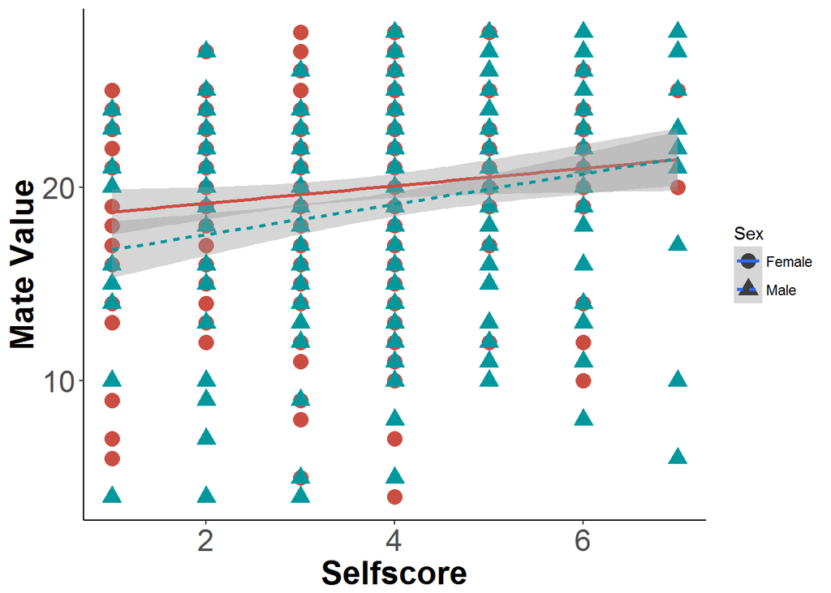

```r
Figure1 <- ggplot(data_gaming, aes(x = Selfscore, y = MV1Total, color = Sex, shape = Sex, linetype = Sex)) +
  geom_point(size = 4) +
  scale_colour_hue(l=50, guide = FALSE) +
  theme_bw() + geom_smooth(method=lm,  fullrange=T) +
  xlab("Selfscore") +
  ylab("Mate Value") +
    theme(axis.line = element_line(colour = "black"),
        axis.text=element_text(size=18),
        axis.title=element_text(size=20,face="bold"),
        axis.title.y=element_text(vjust=0.25),
        axis.title.x=element_text(vjust=0.25),
        panel.grid.major = element_blank(),
        panel.grid.minor = element_blank(),
        panel.border = element_blank(),
        panel.background = element_blank())
Figure1
```

Plotting SGAAverage and age

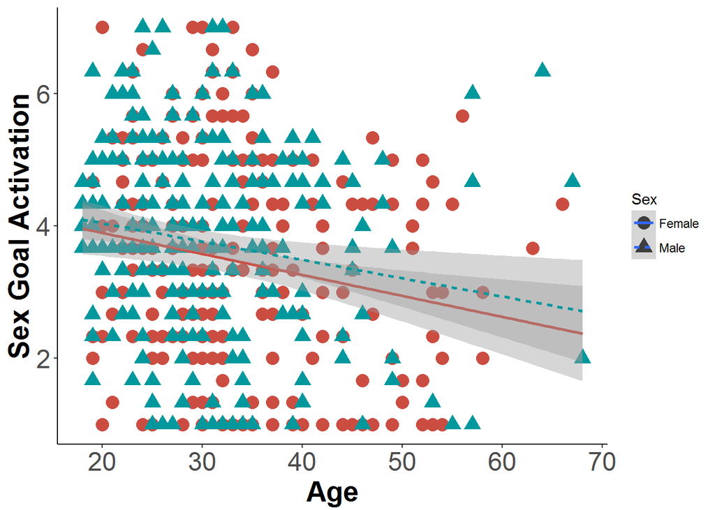

```r
Figure2 <- ggplot(data_gaming, aes(x = Age, y = SGAAverage, color = Sex, shape = Sex, linetype = Sex)) +
  geom_point(size = 4) +
  scale_colour_hue(l=50, guide = FALSE) +
  theme_bw() + geom_smooth(method=lm,  fullrange=T) +
  xlab("Age") +
  ylab("Sex Goal Activation") +
    theme(axis.line = element_line(colour = "black"),
        axis.text=element_text(size=18),
        axis.title=element_text(size=20,face="bold"),
        axis.title.y=element_text(vjust=0.25),
        axis.title.x=element_text(vjust=0.25),
        panel.grid.major = element_blank(),
        panel.grid.minor = element_blank(),
        panel.border = element_blank(),
        panel.background = element_blank())

Figure2
```

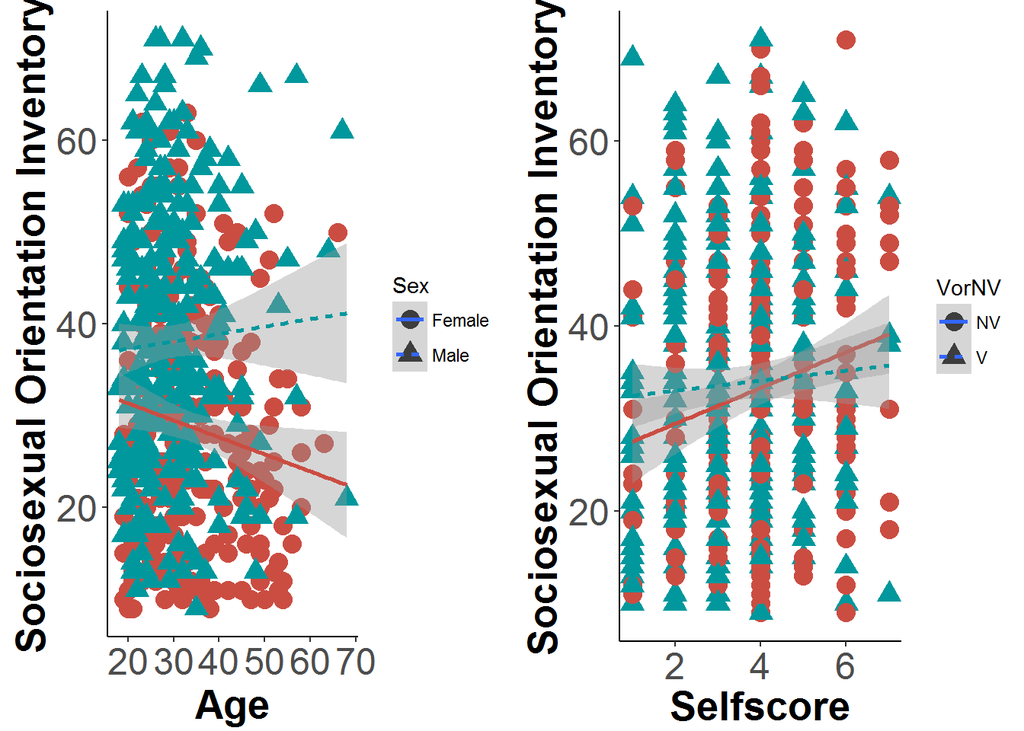

```r
Figure3a <- ggplot(data_gaming, aes(x = Age, y = SOIRTOTAL, color = Sex, shape = Sex, linetype = Sex)) +
  geom_point(size = 4) +
  scale_colour_hue(l=50, guide = FALSE) +
  theme_bw() + geom_smooth(method=lm,  fullrange=T) +
  xlab("Age") +
  ylab("Sociosexual Orientation Inventory") +
    theme(axis.line = element_line(colour = "black"),
        axis.text=element_text(size=18),
        axis.title=element_text(size=20,face="bold"),
        axis.title.y=element_text(vjust=0.25),
        axis.title.x=element_text(vjust=0.25),
        panel.grid.major = element_blank(),
        panel.grid.minor = element_blank(),
        panel.border = element_blank(),
        panel.background = element_blank())

Figure3b <- ggplot(data_gaming, aes(x = Selfscore, y = SOIRTOTAL, color = VorNV, shape = VorNV, linetype = VorNV)) +
  geom_point(size = 4) +
  scale_colour_hue(l=50, guide = FALSE) +
  theme_bw() + geom_smooth(method=lm,  fullrange=T) +
  xlab("Selfscore") +
  ylab("Sociosexual Orientation Inventory") +
    theme(axis.line = element_line(colour = "black"),
        axis.text=element_text(size=18),
        axis.title=element_text(size=20,face="bold"),
        axis.title.y=element_text(vjust=0.25),
        axis.title.x=element_text(vjust=0.25),
        panel.grid.major = element_blank(),
        panel.grid.minor = element_blank(),
        panel.border = element_blank(),
        panel.background = element_blank())

multiplot (Figure3a, Figure3b, cols = 2)
```

## Experiment 2: Rank Manipulation

Are self-scores correlated with the rank they are randomly given in the game

```r
selfrank_corr <- lm(Selfscore  ~  Rank + Sex + VorNV + Age + Rank*Sex + Rank*VorNV, data = data_rank)
anova(selfrank_corr, test="Chisq")
```

```
## Analysis of Variance Table
##
## Response: Selfscore
##             Df  Sum Sq Mean Sq F value    Pr(>F)
## Rank         1    4.96   4.955  2.7259   0.09920 .
## Sex          1   97.66  97.660 53.7236 6.657e-13 ***
## VorNV        1    1.10   1.103  0.6069   0.43624
## Age          1  120.56 120.561 66.3217 1.869e-15 ***
## Rank:Sex     1    2.41   2.409  1.3250   0.25011
## Rank:VorNV   1    5.03   5.027  2.7655   0.09678 .
## Residuals  671 1219.76   1.818
## ---
## Signif. codes:  0 '***' 0.001 '**' 0.01 '*' 0.05 '.' 0.1 ' ' 1
```

```r
ddply(data_rank, .(Sex), summarize, mean=mean(Selfscore), se=sd(Selfscore)/sqrt(length(Selfscore)))
```

```
##      Sex     mean         se
## 1 Female 3.077419 0.08200318
## 2   Male 3.845109 0.07241227
```

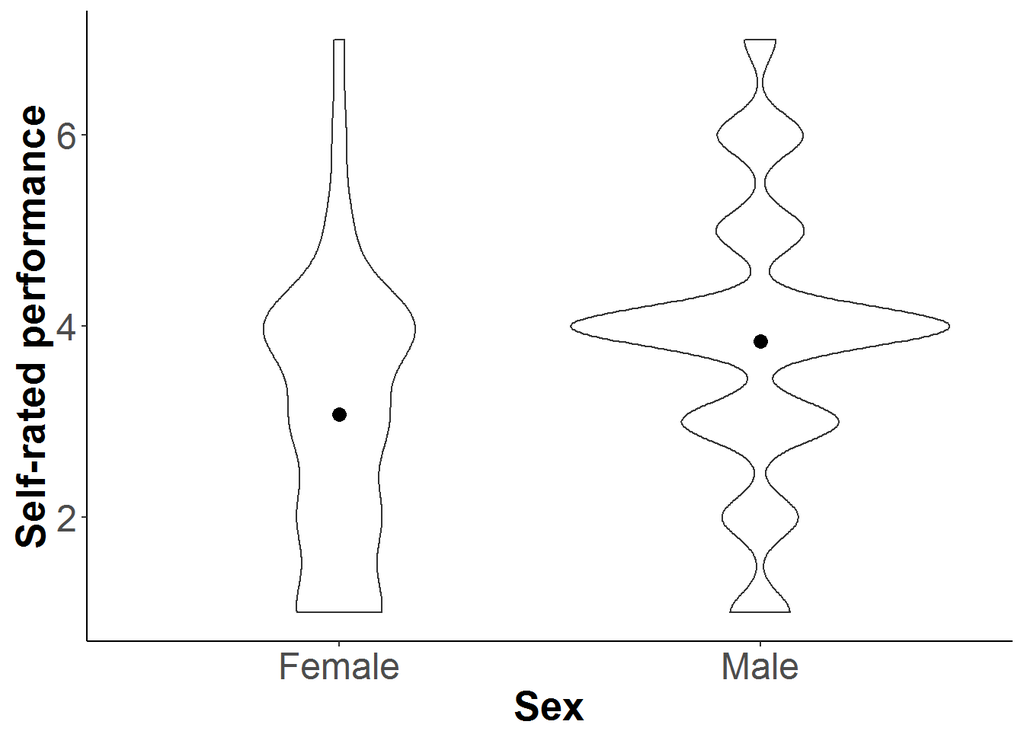

```r
ggplot(data_rank, aes(x=Sex, y=Selfscore)) + geom_violin() + guides(fill=FALSE) +
  xlab("Sex") +
  ylab("Self-rated performance") +
  stat_summary(fun.y="mean", geom="point", size=3) +
  theme(axis.line = element_line(colour = "black"),
        axis.text=element_text(size=18),
        axis.title=element_text(size=20,face="bold"),
        axis.title.y=element_text(vjust=0.25),
        axis.title.x=element_text(vjust=0.25),
        panel.grid.major = element_blank(),
        panel.grid.minor = element_blank(),
        panel.border = element_blank(),
        panel.background = element_blank())
```

## MANOVA

```r
MANOVA_rank<- manova(cbind(MV1Total, SGAAverage, SOIRTOTAL) ~ Rank + VorNV + Age + Sex + Selfscore + Averagefrequencyviolence + VorNV*Selfscore + VorNV*Sex + Age*Sex + Rank*Selfscore + Rank*Sex +Rank*Age, data=data_rank)

summary(MANOVA_rank, test="Pillai")
```

```
##                           Df   Pillai approx F num Df den Df    Pr(>F)
## Rank                       1 0.007452   1.6593      3    663  0.174529
## VorNV                      1 0.001676   0.3710      3    663  0.773986
## Age                        1 0.022059   4.9850      3    663  0.001996 **
## Sex                        1 0.111004  27.5950      3    663 < 2.2e-16 ***
## Selfscore                  1 0.036016   8.2570      3    663 2.124e-05 ***
## Averagefrequencyviolence   1 0.006137   1.3646      3    663  0.252519
## VorNV:Selfscore            1 0.002764   0.6126      3    663  0.606969
## VorNV:Sex                  1 0.004301   0.9546      3    663  0.413748
## Age:Sex                    1 0.006578   1.4633      3    663  0.223368
## Rank:Selfscore             1 0.004055   0.8997      3    663  0.440959
## Rank:Sex                   1 0.008853   1.9740      3    663  0.116573
## Rank:Age                   1 0.001557   0.3447      3    663  0.792981
## Residuals                665
## ---
## Signif. codes:  0 '***' 0.001 '**' 0.01 '*' 0.05 '.' 0.1 ' ' 1
```

```r
summary.aov(MANOVA_rank)
```

```
##  Response MV1Total :
##                           Df  Sum Sq Mean Sq F value    Pr(>F)
## Rank                       1   101.1  101.14  3.4104   0.06523 .
## VorNV                      1     1.3    1.28  0.0432   0.83533
## Age                        1    19.7   19.71  0.6648   0.41517
## Sex                        1     3.2    3.19  0.1075   0.74306
## Selfscore                  1   552.9  552.94 18.6453 1.814e-05 ***
## Averagefrequencyviolence   1    56.4   56.38  1.9011   0.16842
## VorNV:Selfscore            1    24.1   24.15  0.8143   0.36717
## VorNV:Sex                  1    45.3   45.34  1.5288   0.21673
## Age:Sex                    1    18.3   18.35  0.6187   0.43180
## Rank:Selfscore             1     0.4    0.38  0.0127   0.91047
## Rank:Sex                   1    21.6   21.63  0.7294   0.39337
## Rank:Age                   1     5.2    5.18  0.1747   0.67607
## Residuals                665 19721.2   29.66
## ---
## Signif. codes:  0 '***' 0.001 '**' 0.01 '*' 0.05 '.' 0.1 ' ' 1
##
##  Response SGAAverage :
##                           Df  Sum Sq Mean Sq F value  Pr(>F)
## Rank                       1    4.64  4.6406  1.8618 0.17288
## VorNV                      1    0.45  0.4462  0.1790 0.67236
## Age                        1   24.18 24.1819  9.7016 0.00192 **
## Sex                        1    7.80  7.8005  3.1295 0.07734 .
## Selfscore                  1   15.45 15.4544  6.2002 0.01302 *
## Averagefrequencyviolence   1    6.99  6.9916  2.8050 0.09444 .
## VorNV:Selfscore            1    0.26  0.2624  0.1053 0.74570
## VorNV:Sex                  1    3.01  3.0087  1.2071 0.27231
## Age:Sex                    1    3.70  3.6989  1.4840 0.22358
## Rank:Selfscore             1    0.25  0.2500  0.1003 0.75156
## Rank:Sex                   1   14.20 14.2023  5.6979 0.01726 *
## Rank:Age                   1    1.71  1.7060  0.6845 0.40835
## Residuals                665 1657.56  2.4926
## ---
## Signif. codes:  0 '***' 0.001 '**' 0.01 '*' 0.05 '.' 0.1 ' ' 1
##
##  Response SOIRTOTAL :
##                           Df Sum Sq Mean Sq F value  Pr(>F)
## Rank                       1    164   164.4  0.6872 0.40743
## VorNV                      1    244   244.0  1.0200 0.31289
## Age                        1   1290  1289.5  5.3905 0.02055 *
## Sex                        1  19819 19819.1 82.8490 < 2e-16 ***
## Selfscore                  1    388   387.9  1.6217 0.20330
## Averagefrequencyviolence   1     36    36.4  0.1522 0.69659
## VorNV:Selfscore            1    209   208.9  0.8734 0.35035
## VorNV:Sex                  1     68    68.1  0.2849 0.59370
## Age:Sex                    1    744   743.5  3.1081 0.07836 .
## Rank:Selfscore             1    569   569.3  2.3799 0.12338
## Rank:Sex                   1     40    40.1  0.1676 0.68235
## Rank:Age                   1      2     2.1  0.0088 0.92526
## Residuals                665 159081   239.2
## ---
## Signif. codes:  0 '***' 0.001 '**' 0.01 '*' 0.05 '.' 0.1 ' ' 1
```

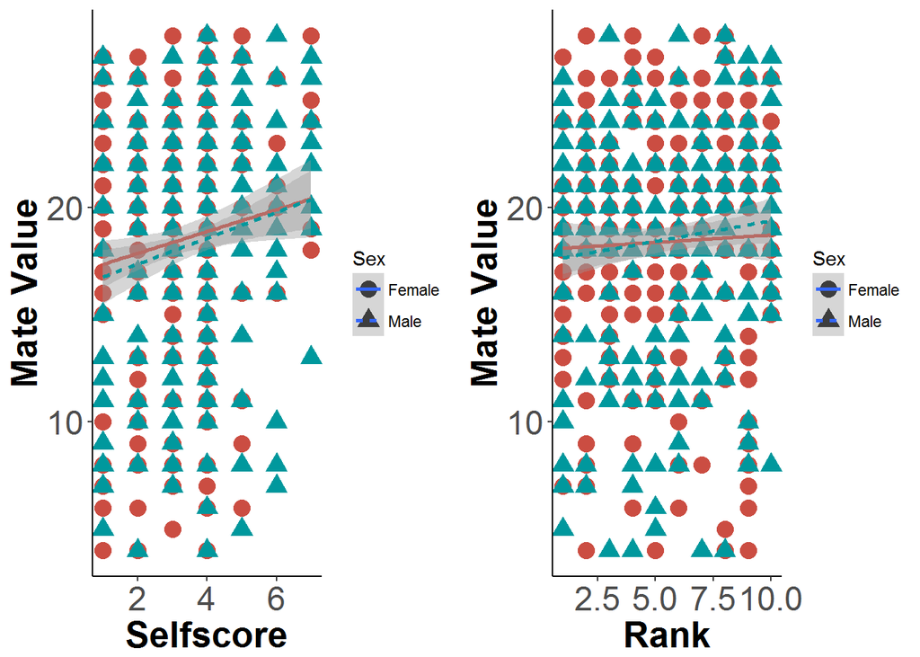

```r
Figure4a <- ggplot(data_rank, aes(x = Selfscore, y = MV1Total, color = Sex, shape = Sex, linetype = Sex)) +
  geom_point(size = 4) +
  scale_colour_hue(l=50, guide = FALSE) +
  theme_bw() + geom_smooth(method=lm,  fullrange=T) +
  xlab("Selfscore") +
  ylab("Mate Value") +
    theme(axis.line = element_line(colour = "black"),
        axis.text=element_text(size=18),
        axis.title=element_text(size=20,face="bold"),
        axis.title.y=element_text(vjust=0.25),
        axis.title.x=element_text(vjust=0.25),
        panel.grid.major = element_blank(),
        panel.grid.minor = element_blank(),
        panel.border = element_blank(),
        panel.background = element_blank())

Figure4b <- ggplot(data_rank, aes(x = Rank, y = MV1Total, color = Sex, shape = Sex, linetype = Sex)) +
  geom_point(size = 4) +
  scale_colour_hue(l=50, guide = FALSE) +
  theme_bw() + geom_smooth(method=lm,  fullrange=T) +
  xlab("Rank") +
  ylab("Mate Value") +
    theme(axis.line = element_line(colour = "black"),
        axis.text=element_text(size=18),
        axis.title=element_text(size=20,face="bold"),
        axis.title.y=element_text(vjust=0.25),
        axis.title.x=element_text(vjust=0.25),
        panel.grid.major = element_blank(),
        panel.grid.minor = element_blank(),
        panel.border = element_blank(),
        panel.background = element_blank())

multiplot(Figure4a, Figure4b, cols = 2)
```

Plotting SGAAverage and age and sex Then SGAverage and selfscore

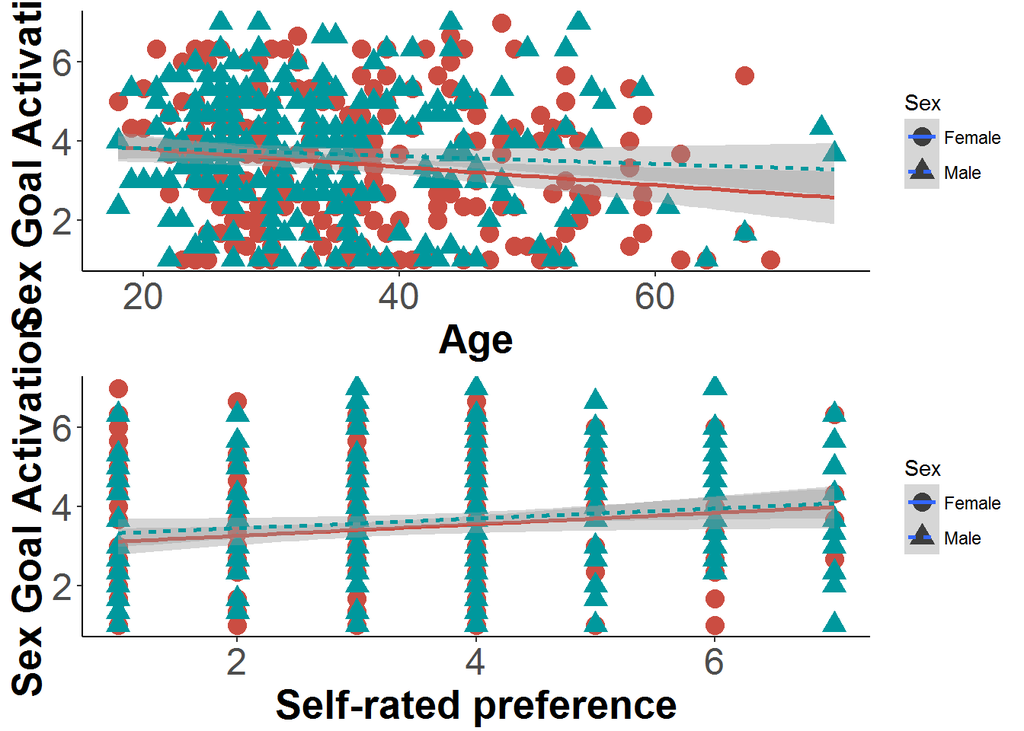

```r
Figure5a <- ggplot(data_rank, aes(x = Age, y = SGAAverage, color = Sex, shape = Sex, linetype = Sex)) +
  geom_point(size = 4) +
  scale_colour_hue(l=50, guide = FALSE) +
  theme_bw() + geom_smooth(method=lm,  fullrange=T) +
  xlab("Age") +
  ylab("Sex Goal Activation") +
    theme(axis.line = element_line(colour = "black"),
        axis.text=element_text(size=18),
        axis.title=element_text(size=20,face="bold"),
        axis.title.y=element_text(vjust=0.25),
        axis.title.x=element_text(vjust=0.25),
        panel.grid.major = element_blank(),
        panel.grid.minor = element_blank(),
        panel.border = element_blank(),
        panel.background = element_blank())

Figure5b <- ggplot(data_rank, aes(x = Selfscore, y = SGAAverage, color = Sex, shape = Sex, linetype = Sex)) +
  geom_point(size = 4) +
  scale_colour_hue(l=50, guide = FALSE) +
  theme_bw() + geom_smooth(method=lm,  fullrange=T) +
  xlab("Self-rated preference") +
  ylab("Sex Goal Activation") +
    theme(axis.line = element_line(colour = "black"),
        axis.text=element_text(size=18),
        axis.title=element_text(size=20,face="bold"),
        axis.title.y=element_text(vjust=0.25),
        axis.title.x=element_text(vjust=0.25),
        panel.grid.major = element_blank(),
        panel.grid.minor = element_blank(),
        panel.border = element_blank(),
        panel.background = element_blank())

multiplot(Figure5a, Figure5b, cols =)
```

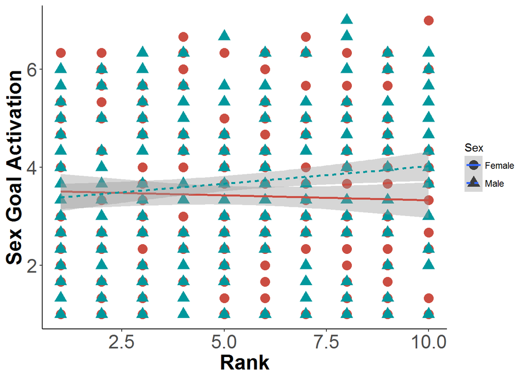

```r
Figure6 <- ggplot(data_rank, aes(x = Rank, y = SGAAverage, color = Sex, shape = Sex, linetype = Sex)) +
  geom_point(size = 4) +
  scale_colour_hue(l=50, guide = FALSE) +
  theme_bw() + geom_smooth(method=lm,  fullrange=T) +
  xlab("Rank") +
  ylab("Sex Goal Activation") +
    theme(axis.line = element_line(colour = "black"),
        axis.text=element_text(size=18),
        axis.title=element_text(size=20,face="bold"),
        axis.title.y=element_text(vjust=0.25),
        axis.title.x=element_text(vjust=0.25),
        panel.grid.major = element_blank(),
        panel.grid.minor = element_blank(),
        panel.border = element_blank(),
        panel.background = element_blank())

Figure6
```

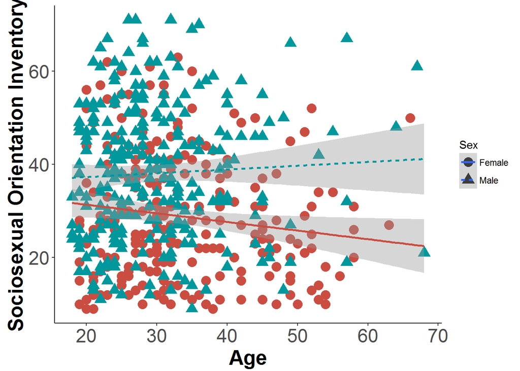

```r
Figure7 <- ggplot(data_gaming, aes(x = Age, y = SOIRTOTAL, color = Sex, shape = Sex, linetype = Sex)) +
  geom_point(size = 4) +
  scale_colour_hue(l=50, guide = FALSE) +
  theme_bw() + geom_smooth(method=lm,  fullrange=T) +
  xlab("Age") +
  ylab("Sociosexual Orientation Inventory") +
    theme(axis.line = element_line(colour = "black"),
        axis.text=element_text(size=18),
        axis.title=element_text(size=20,face="bold"),
        axis.title.y=element_text(vjust=0.25),
        axis.title.x=element_text(vjust=0.25),
        panel.grid.major = element_blank(),
        panel.grid.minor = element_blank(),
        panel.border = element_blank(),
        panel.background = element_blank())
Figure7
```

## Experiment 3: Face Choices

Do men and women differ in how well they performed in the game in both self-rated (selfscore) and actual performance

```r
Perf <- lm(Selfscore ~  Age + Sex + VorNV + Age*VorNV + Sex*VorNV, data = data_faces)
anova(Perf, test="Chisq")
```

```
## Analysis of Variance Table
##
## Response: Selfscore
##            Df Sum Sq Mean Sq F value    Pr(>F)
## Age         1  52.57  52.571 33.2947 1.551e-08 ***
## Sex         1  11.68  11.679  7.3969  0.006808 **
## VorNV       1  58.16  58.158 36.8332 2.904e-09 ***
## Age:VorNV   1   0.16   0.159  0.1009  0.750892
## Sex:VorNV   1   0.75   0.750  0.4751  0.491043
## Residuals 415 655.27   1.579
## ---
## Signif. codes:  0 '***' 0.001 '**' 0.01 '*' 0.05 '.' 0.1 ' ' 1
```

```r
summary(Perf, test="Chisq")
```

```
##
## Call:
## lm(formula = Selfscore ~ Age + Sex + VorNV + Age * VorNV + Sex *
##     VorNV, data = data_faces)
##
## Residuals:
##     Min      1Q  Median      3Q     Max
## -3.0927 -0.7844  0.0411  0.7238  3.4186
##
## Coefficients:
##                 Estimate Std. Error t value Pr(>|t|)
## (Intercept)     4.965550   0.334981  14.823  < 2e-16 ***
## Age            -0.034914   0.008855  -3.943 9.45e-05 ***
## SexMale         0.285223   0.175557   1.625    0.105
## VorNVV         -0.736595   0.497301  -1.481    0.139
## Age:VorNVV     -0.003195   0.013154  -0.243    0.808
## SexMale:VorNVV  0.172370   0.250079   0.689    0.491
## ---
## Signif. codes:  0 '***' 0.001 '**' 0.01 '*' 0.05 '.' 0.1 ' ' 1
##
## Residual standard error: 1.257 on 415 degrees of freedom
## Multiple R-squared:  0.1584, Adjusted R-squared:  0.1482
## F-statistic: 15.62 on 5 and 415 DF,  p-value: 4.292e-14
```

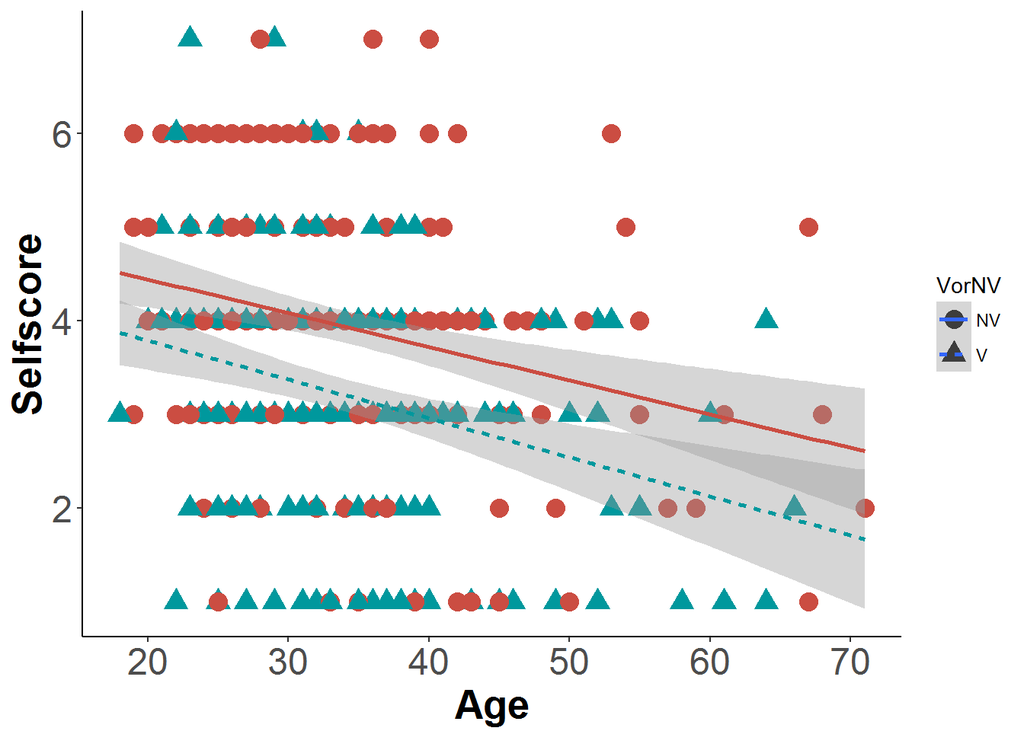

```r
ggplot(data_faces, aes(x = Age, y = Selfscore, color = VorNV, shape = VorNV, linetype = VorNV)) +
  geom_point(size = 4) +
  scale_colour_hue(l=50, guide = FALSE) +
  theme_bw() + geom_smooth(method=lm,  fullrange=T) +
  xlab("Age") +
  ylab("Selfscore") +
    theme(axis.line = element_line(colour = "black"),
        axis.text=element_text(size=18),
        axis.title=element_text(size=20,face="bold"),
        axis.title.y=element_text(vjust=0.25),
        axis.title.x=element_text(vjust=0.25),
        panel.grid.major = element_blank(),
        panel.grid.minor = element_blank(),
        panel.border = element_blank(),
        panel.background = element_blank())
```

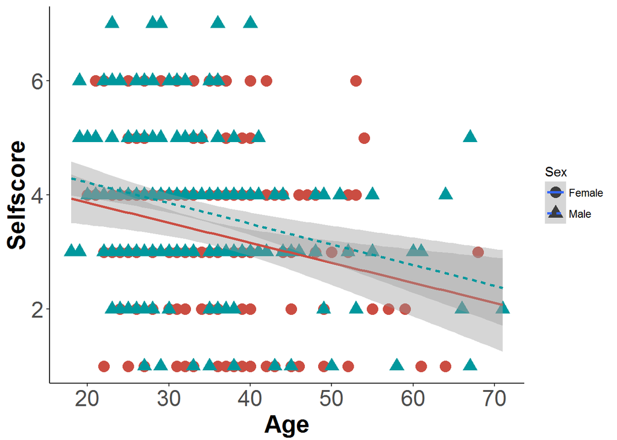

```r
ggplot(data_faces, aes(x = Age, y = Selfscore, color = Sex, shape = Sex, linetype = Sex)) +
  geom_point(size = 4) +
  scale_colour_hue(l=50, guide = FALSE) +
  theme_bw() + geom_smooth(method=lm,  fullrange=T) +
  xlab("Age") +
  ylab("Selfscore") +
    theme(axis.line = element_line(colour = "black"),
        axis.text=element_text(size=18),
        axis.title=element_text(size=20,face="bold"),
        axis.title.y=element_text(vjust=0.25),
        axis.title.x=element_text(vjust=0.25),
        panel.grid.major = element_blank(),
        panel.grid.minor = element_blank(),
        panel.border = element_blank(),
        panel.background = element_blank())
```

```r
##Need to find some way to standardize the scores within game category
##Nevermind...people lied with their scores so standardizing doesn't make a difference
```

## MANOVA

```r
MANOVA_face<- manova(cbind(MV1Total, SGAAverage, SOIRTOTAL) ~ VorNV + Age + Sex + Selfscore + Averagefrequencyviolence +  VorNV*Selfscore + VorNV*Sex + Age*Sex, data=data_faces)
summary(MANOVA_face, test="Pillai")
```

```
##                           Df   Pillai approx F num Df den Df    Pr(>F)
## VorNV                      1 0.002736   0.3749      3    410   0.77114
## Age                        1 0.013707   1.8993      3    410   0.12906
## Sex                        1 0.118335  18.3431      3    410 3.472e-11 ***
## Selfscore                  1 0.013831   1.9168      3    410   0.12620
## Averagefrequencyviolence   1 0.015304   2.1241      3    410   0.09658 .
## VorNV:Selfscore            1 0.007264   1.0001      3    410   0.39271
## VorNV:Sex                  1 0.021304   2.9749      3    410   0.03150 *
## Age:Sex                    1 0.003840   0.5269      3    410   0.66406
## Residuals                412
## ---
## Signif. codes:  0 '***' 0.001 '**' 0.01 '*' 0.05 '.' 0.1 ' ' 1
```

```r
summary.aov(MANOVA_face)
```

```
##  Response MV1Total :
##                           Df Sum Sq Mean Sq F value  Pr(>F)
## VorNV                      1   12.7  12.719  0.6088 0.43567
## Age                        1   15.8  15.799  0.7563 0.38500
## Sex                        1   71.8  71.841  3.4390 0.06439 .
## Selfscore                  1  112.7 112.706  5.3952 0.02068 *
## Averagefrequencyviolence   1   14.2  14.197  0.6796 0.41019
## VorNV:Selfscore            1   10.4  10.393  0.4975 0.48099
## VorNV:Sex                  1   19.1  19.054  0.9121 0.34012
## Age:Sex                    1    0.6   0.626  0.0300 0.86265
## Residuals                412 8606.7  20.890
## ---
## Signif. codes:  0 '***' 0.001 '**' 0.01 '*' 0.05 '.' 0.1 ' ' 1
##
##  Response SGAAverage :
##                           Df  Sum Sq Mean Sq F value  Pr(>F)
## VorNV                      1    0.39  0.3877  0.1584 0.69081
## Age                        1    1.57  1.5665  0.6401 0.42414
## Sex                        1    3.11  3.1063  1.2692 0.26056
## Selfscore                  1    1.94  1.9407  0.7930 0.37372
## Averagefrequencyviolence   1    8.47  8.4688  3.4604 0.06357 .
## VorNV:Selfscore            1    4.72  4.7235  1.9301 0.16550
## VorNV:Sex                  1    4.51  4.5091  1.8425 0.17540
## Age:Sex                    1    2.44  2.4419  0.9978 0.31843
## Residuals                412 1008.30  2.4473
## ---
## Signif. codes:  0 '***' 0.001 '**' 0.01 '*' 0.05 '.' 0.1 ' ' 1
##
##  Response SOIRTOTAL :
##                           Df Sum Sq Mean Sq F value    Pr(>F)
## VorNV                      1     65    65.2  0.3095  0.578319
## Age                        1   1072  1072.5  5.0864  0.024639 *
## Sex                        1  10626 10626.2 50.3974 5.534e-12 ***
## Selfscore                  1      0     0.2  0.0007  0.978241
## Averagefrequencyviolence   1    306   305.8  1.4506  0.229129
## VorNV:Selfscore            1    117   117.2  0.5557  0.456435
## VorNV:Sex                  1   1425  1424.9  6.7580  0.009668 **
## Age:Sex                    1    162   162.0  0.7685  0.381199
## Residuals                412  86870   210.8
## ---
## Signif. codes:  0 '***' 0.001 '**' 0.01 '*' 0.05 '.' 0.1 ' ' 1
```

Plot Mate Value

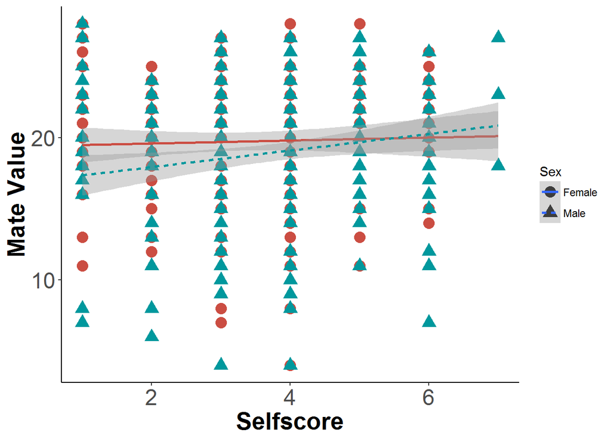

```r
Figure8 <- ggplot(data_faces, aes(x = Selfscore, y = MV1Total, color = Sex, shape = Sex, linetype = Sex)) +
  geom_point(size = 4) +
  scale_colour_hue(l=50, guide = FALSE) +
  theme_bw() + geom_smooth(method=lm,  fullrange=T) +
  xlab("Selfscore") +
  ylab("Mate Value") +
    theme(axis.line = element_line(colour = "black"),
        axis.text=element_text(size=18),
        axis.title=element_text(size=20,face="bold"),
        axis.title.y=element_text(vjust=0.25),
        axis.title.x=element_text(vjust=0.25),
        panel.grid.major = element_blank(),
        panel.grid.minor = element_blank(),
        panel.border = element_blank(),
        panel.background = element_blank())
Figure8
```

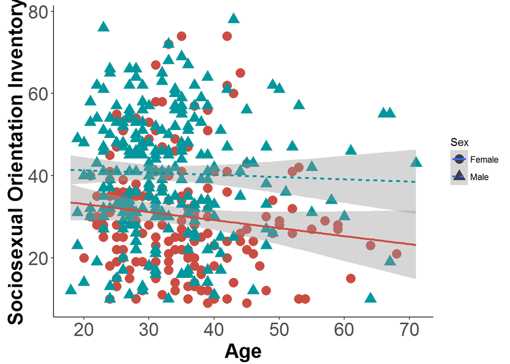

```r
Figure9 <- ggplot(data_faces, aes(x = Age, y = SOIRTOTAL, color = Sex, shape = Sex, linetype = Sex)) +
  geom_point(size = 4) +
  scale_colour_hue(l=50, guide = FALSE) +
  theme_bw() + geom_smooth(method=lm,  fullrange=T) +
  xlab("Age") +
  ylab("Sociosexual Orientation Inventory") +
    theme(axis.line = element_line(colour = "black"),
        axis.text=element_text(size=18),
        axis.title=element_text(size=20,face="bold"),
        axis.title.y=element_text(vjust=0.25),
        axis.title.x=element_text(vjust=0.25),
        panel.grid.major = element_blank(),
        panel.grid.minor = element_blank(),
        panel.border = element_blank(),
        panel.background = element_blank())
Figure9
```

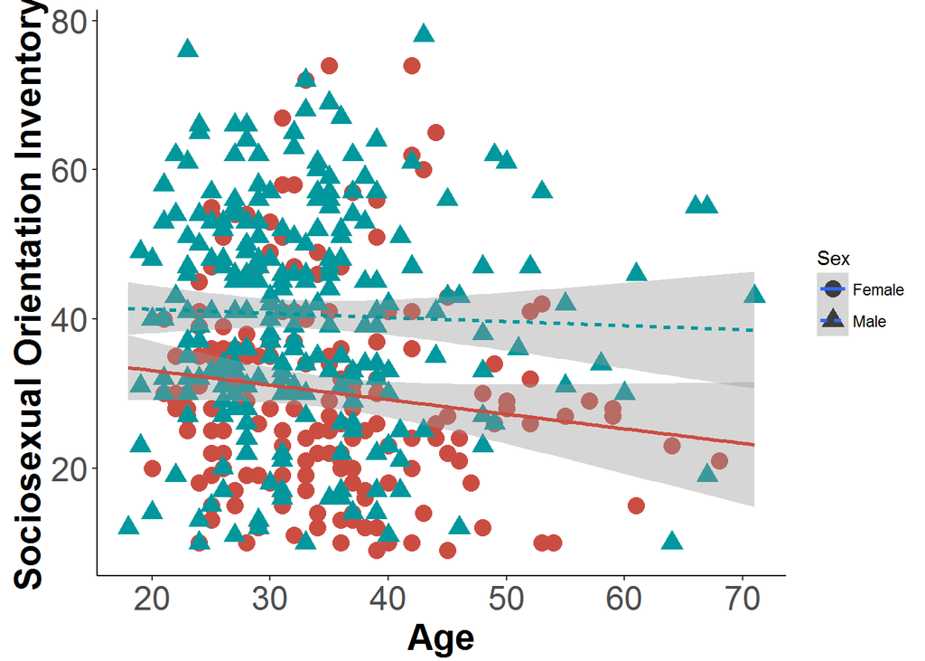

```r
Figure10 <- ggplot(data_faces, aes(x = Age, y = SOIRTOTAL, color = Sex, shape = Sex, linetype = Sex)) +
  geom_point(size = 4) +
  scale_colour_hue(l=50, guide = FALSE) +
  theme_bw() + geom_smooth(method=lm,  fullrange=T) +
  xlab("Age") +
  ylab("Sociosexual Orientation Inventory") +
    theme(axis.line = element_line(colour = "black"),
        axis.text=element_text(size=18),
        axis.title=element_text(size=20,face="bold"),
        axis.title.y=element_text(vjust=0.25),
        axis.title.x=element_text(vjust=0.25),
        panel.grid.major = element_blank(),
        panel.grid.minor = element_blank(),
        panel.border = element_blank(),
        panel.background = element_blank())

Figure10
```

Short term faces:

```r
STselection <- lm(TotalSTScore ~  VorNV + Age + Sex + Selfscore + MV1Total + SGAAverage + SOIRTOTAL + Sex*Selfscore, data=data_faces)

anova(STselection)
```

```
## Analysis of Variance Table
##
## Response: TotalSTScore
##                Df Sum Sq Mean Sq F value   Pr(>F)
## VorNV           1   0.25  0.2531  0.1233 0.725632
## Age             1   0.01  0.0068  0.0033 0.954164
## Sex             1  28.20 28.1964 13.7373 0.000239 ***
## Selfscore       1   1.12  1.1239  0.5475 0.459744
## MV1Total        1   0.01  0.0083  0.0040 0.949439
## SGAAverage      1   0.01  0.0121  0.0059 0.938840
## SOIRTOTAL       1   4.14  4.1354  2.0148 0.156531
## Sex:Selfscore   1  12.18 12.1782  5.9332 0.015281 *
## Residuals     412 845.65  2.0525
## ---
## Signif. codes:  0 '***' 0.001 '**' 0.01 '*' 0.05 '.' 0.1 ' ' 1
```

[figure not shown]

```r
Figure11 <- ggplot(data_faces, aes(x = Selfscore, y = TotalSTScore, color = Sex, shape = Sex, linetype = Sex)) +
  geom_point(size = 4) +
  ylim(0,7.5) +
  scale_colour_hue(l=50, guide = FALSE) +
  scale_x_continuous(limits=c(0,7.5)) +
  theme_bw() + geom_smooth(method=lm,  fullrange=T) +
  xlab("Short-term Facial Preference for masculinity") +
  ylab("Self Rated Score") +
  theme(legend.position="right") +
  theme(axis.line = element_line(colour = "black"),
        axis.text=element_text(size=18),
        axis.title=element_text(size=20,face="bold"),
        axis.title.y=element_text(vjust=0.25),
        axis.title.x=element_text(vjust=0.25),
        panel.grid.major = element_blank(),
        panel.grid.minor = element_blank(),
        panel.border = element_blank(),
        panel.background = element_blank())

Figure11
```

```r
LTselection <- lm(TotalLTScore ~  + VorNV + Age + Sex + MV1Total + SGAAverage + SOIRTOTAL + Sex*Selfscore, data=data_faces)

anova(LTselection)
```

```
## Analysis of Variance Table
##
## Response: TotalLTScore
##                Df  Sum Sq Mean Sq F value   Pr(>F)
## VorNV           1    4.47  4.4667  1.8230 0.177693
## Age             1   23.69 23.6903  9.6690 0.002004 **
## Sex             1   17.17 17.1702  7.0079 0.008427 **
## MV1Total        1    1.07  1.0672  0.4356 0.509634
## SGAAverage      1    0.58  0.5768  0.2354 0.627809
## SOIRTOTAL       1   16.45 16.4522  6.7148 0.009901 **
## Selfscore       1    1.90  1.8999  0.7754 0.379052
## Sex:Selfscore   1    0.04  0.0414  0.0169 0.896618
## Residuals     412 1009.46  2.4501
## ---
## Signif. codes:  0 '***' 0.001 '**' 0.01 '*' 0.05 '.' 0.1 ' ' 1
```

LT Faces and age

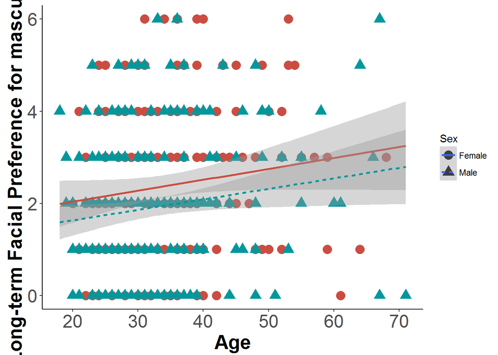

```r
Figure12 <- ggplot(data_faces, aes(x = Age, y = TotalLTScore, color = Sex, shape = Sex, linetype = Sex)) +
  geom_point(size = 4) +
  scale_colour_hue(l=50, guide = FALSE) +
  theme_bw() + geom_smooth(method=lm,  fullrange=T) +
  xlab("Age") +
  ylab("Long-term Facial Preference for masculinity") +
  theme(legend.position="right") +
  theme(axis.line = element_line(colour = "black"),
        axis.text=element_text(size=18),
        axis.title=element_text(size=20,face="bold"),
        axis.title.y=element_text(vjust=0.25),
        axis.title.x=element_text(vjust=0.25),
        panel.grid.major = element_blank(),
        panel.grid.minor = element_blank(),
        panel.border = element_blank(),
        panel.background = element_blank())

Figure12
```

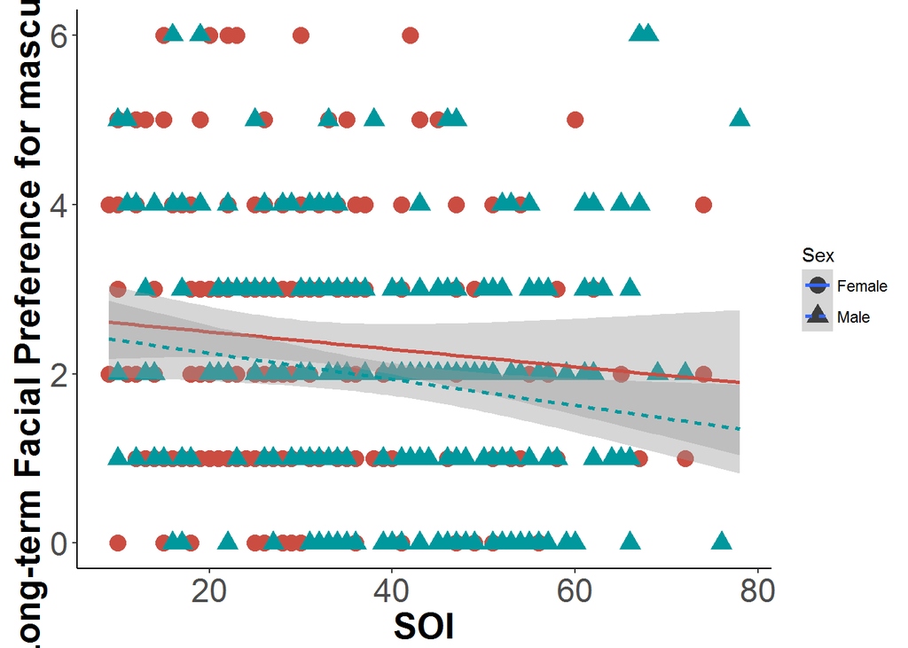

```r
Figure13 <- ggplot(data_faces, aes(x = SOIRTOTAL, y = TotalLTScore, color = Sex, shape = Sex, linetype = Sex)) +
  geom_point(size = 4) +
  scale_colour_hue(l=50, guide = FALSE) +
  theme_bw() + geom_smooth(method=lm,  fullrange=T) +
  xlab("SOI") +
  ylab("Long-term Facial Preference for masculinity") +
  theme(legend.position="right") +
  theme(axis.line = element_line(colour = "black"),
        axis.text=element_text(size=18),
        axis.title=element_text(size=20,face="bold"),
        axis.title.y=element_text(vjust=0.25),
        axis.title.x=element_text(vjust=0.25),
        panel.grid.major = element_blank(),
        panel.grid.minor = element_blank(),
        panel.border = element_blank(),
        panel.background = element_blank())
Figure13
```